# quickstart

```r
library(bram)
library(brms)
```

# Define the model

Firstly, define the formula, data, and family for the model as follows, using brms syntax:

```r
model <- bram(cyl ~ scale(hp) + scale(disp), data=mtcars, family="poisson")
```

# Get, set and check priors

The prior setting and checking process can be tricky. To simplify things, in bram the priors that need to be set can be viewed using the `$get_priors()` function:

```r
model$get_priors()
```

```
#>                   prior     class      coef group resp dpar nlpar lb ub
#>                  (flat)         b
#>                  (flat)         b scaledisp
#>                  (flat)         b   scalehp
#>  student_t(3, 1.8, 2.5) Intercept
#>        source
#>       default
#>  (vectorized)
#>  (vectorized)
#>       default
```

The three priors for the intercept and two predictors now need to be set. The next phase of model fitting will be an iterative process of setting and checking the priors and the implications they make. The model can be checked against both the distribution of predictions for the response variable, but also the implied a priori marginal effects in the model. This phase will look something like:

```r
priors <- c(
  prior(normal(0, 0.5), coef="scalehp"),
  prior(normal(0, 0.8), coef="scaledisp"),
  prior(normal(1, 1), class="Intercept")
)
model$set_priors(priors)
model$prior_check()
```

[output not shown]

[output cut: 44 more lines]

[output not shown]

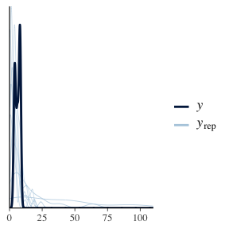

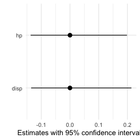

Once the response variables are within the correct range, and the marginal effects match up with prior expectations, we’re ready to fit the model. In this case the priors were set so the marginal effects of the two variables are relatively similar, as I have no prior information about which variable is more important, and both variables are scaled.

The model, with its previously defined priors, can be fit using:

```r
model$fit()
```

[output not shown]

[output cut: 43 more lines]

[output not shown]

To check the model diagnostics (traceplots, summary statistics), run:

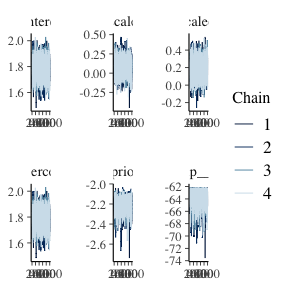

```
#>  Family: poisson
#>   Links: mu = log
#> Formula: cyl ~ scale(hp) + scale(disp)
#>    Data: self$data (Number of observations: 32)
#>   Draws: 4 chains, each with iter = 2000; warmup = 1000; thin = 1;
#>          total post-warmup draws = 4000
#>
#> Population-Level Effects:
#>           Estimate Est.Error l-95% CI u-95% CI Rhat Bulk_ESS Tail_ESS
#> Intercept     1.78      0.07     1.63     1.92 1.00     2487     2336
#> scalehp       0.09      0.11    -0.13     0.29 1.00     1951     2307
#> scaledisp     0.18      0.11    -0.03     0.40 1.00     1893     2284
#>
#> Draws were sampled using sample(hmc). For each parameter, Bulk_ESS
#> and Tail_ESS are effective sample size measures, and Rhat is the potential
#> scale reduction factor on split chains (at convergence, Rhat = 1).
```

```r
model$diagnostics()
```

A summary of the effects implied by the model once it has been fit to the data can be accessed using the `$summary()` function. We are usually interested in the marginal effects, that is, the expected difference in the response of a unit difference in a predictor variable, when all else is held constant. This information is not always contained in the coefficients, so this function provides average marginal effects calculated using the `marginaleffects` package:

```r
model$summary()
```

```
#>   Term   Effect     2.5 %  97.5 %
#> 1   hp 0.008213 -0.011270 0.02597
#> 2 disp 0.008930 -0.001499 0.01999
#>
#> Model type:  brmsfit
#> Prediction type:  response
```

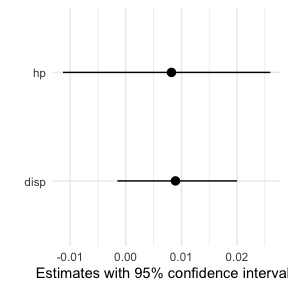